# Evaluating and Refining Groundfish Risk Tables for ABC Reductions Under Exceptional Circumstances

- Show All Code
- Hide All Code
- View Source

Published

May 5, 2026

## Summary

This report looks at whether groundfish risk table scores help explain when the Scientific and Statistical Committee (SSC) recommends setting ABC below the maximum permissible ABC. In simple terms, it asks whether higher or more widespread concerns in the risk table tend to line up with larger reductions.

The answer is yes, but only partly. Stocks with more elevated concerns often do receive larger reductions, and population dynamics concerns appear to be especially informative. At the same time, the relationship is not tight enough to treat the risk table as a formula. Similar score patterns can still lead to different reductions because the SSC also considers stock-specific context, model behavior, and management judgment.

The results should therefore be read as descriptive rather than prescriptive. They summarize how risk table scores and SSC reductions have lined up in the historical record, but they do not provide a mechanical rule for future decisions.

## Introduction

The North Pacific Fishery Management Council’s Scientific and Statistical Committee (SSC) may set ABCs below the maximum permissible ABC (maxABC) when the assessment risk table identifies elevated concerns. The risk table scores four categories—Assessment-related (A), Population dynamics (P), Ecosystem (E), and Fishery-informed (F)—on a scale where scores >1 indicate concern.

This analysis uses the *Groundfish Risk Table Report: 2024 Update*, presented under agenda item C1 at the December 2024 Council meeting, as its source document for the historical risk-table record (Shotwell and Bryan 2024). That report collated risk table information for Alaska groundfish stocks in the Bering Sea and Aleutian Islands (BSAI) and the Gulf of Alaska (GOA) from 2018 onward and framed the summary as a living reference for stock assessment authors and reviewers.

The report emphasizes that risk table implementation changed substantially over the 2018-2024 period (Shotwell and Bryan 2024). The 2018 trial year included only a small number of completed tables and only three categories: assessment, population dynamics, and ecosystem. Fishery performance was added in 2019. In response to SSC direction, the scoring system was later reduced from four levels to three beginning in 2023, and the category descriptions were revised again for 2024 to better cover the intended range of conditions. Those shifts make direct comparisons across years imperfect, especially when contrasting the 2018 trial year and the reduced-level years from 2023 onward with the 2019-2022 period.

The AFSC working group summarized annual category scores, the maximum score across categories, author-proposed reductions, SSC-recommended reductions, methods used to derive reductions, and cases where author, Plan Team, and SSC recommendations differed (Shotwell and Bryan 2024). Across 2018-2024, the report identified 136 completed risk tables: 77 with at least one elevated score, 59 without elevated scores, 25 with an author recommendation to reduce from maximum ABC, and 28 with a final reduction following Plan Team and SSC review. The relatively small number of reductions compared with the number of risk tables is central to the interpretation here: risk table scores are informative, but they are not determinative on their own.

This document narrows that broader report into a modeling exercise. It focuses on the relationship between risk table scores and the magnitude of the SSC’s recommended reduction from maxABC, and evaluates several candidate models for describing those reductions.

### How the risk table framework evolved

Several design changes matter for interpretation of any time series built from these scores:

1. In 2018, risk tables were used on a limited trial basis and included only assessment, population dynamics, and ecosystem categories.
2. In 2019, fishery performance was added as a fourth category.
3. In 2023, the four scoring levels were reduced to three: normal, increased, and extreme. Under that reduced system, current levels 2 and 3 are roughly comparable to the earlier levels 3 and 4.
4. In 2024, the text defining the categories was updated after the SSC asked for descriptions that better covered the full intended range of conditions.

These changes mean the raw scores are not fully stationary through time. Any model fit to the combined record should therefore be treated as descriptive of historical SSC behavior rather than as a stable calibration of a fixed scoring system.

### How reductions have been derived in practice

The 2024 summary report documented several approaches authors and reviewers have used when moving from elevated scores to a reduction from maxABC. Those approaches include:

1. Deferring to the SSC to specify a reduction if one was judged warranted.
2. Applying tier-based advice developed for one stock status category to another, such as Tier 3-style advice used for Tier 1 stocks.
3. Using prior projection results when a previous scenario better captured the concern driving the reduction.
4. Applying probability-based methods such as the Thompson framework for translating elevated risk into a buffer below maxABC.
5. Selecting an ABC level intended to keep the stock above a biological threshold such as B20%.
6. Using an alternative model configuration with better retrospective performance or lower OFL and ABC values.
7. Taking a stair-step approach between the current-year estimate and a previous projection.
8. Adjusting recent recruitment assumptions or the reference period used in projections.

That diversity in methods is important for interpreting the results below. The same nominal risk score can map to different reductions depending on stock status, model structure, and the rationale judged most relevant by the SSC.

## Data

The data below come from SSC-recommended reductions only (not Plan Team or author recommendations). Rollover years and records without a quantified reduction are excluded. Blank years in the broader report generally correspond to off-cycle assessments with no new risk table, although a reduction may still carry over from an earlier decision. The analysis dataset below is therefore a filtered subset of the full living summary rather than a complete reproduction of every annual stock entry.

Table 1 is the core analytical dataset used throughout the document. It provides the stock-year observations, the category-level elevated scores used as predictors, and the SSC reduction used as the response variable. The derived columns summarize two distinct ideas that recur in the figures and models below: overall severity through the total score, and breadth of concern through the number of elevated categories.

```r
dat <- tribble(
  ~stock,                            ~year, ~A, ~P, ~E, ~F, ~pct_red,
  "EBS Pollock",                      2018,  0,  2,  2,  0,  30,
  "EBS Pollock",                      2019,  0,  2,  2,  2,  43,
  "EBS Pollock",                      2020,  0,  0,  2,  2,  30,
  "EBS Pollock",                      2021,  2,  0,  2,  2,  11,
  "EBS Pollock",                      2022,  2,  0,  0,  0,  43,
  "EBS Pollock",                      2023,  0,  0,  2,  0,  18,
  "EBS Pacific cod",                  2019,  0,  0,  2,  0,   3,
  "AI Pacific cod",                   2023,  0,  2,  2,  0,  10,
  "AK Sablefish",                     2018,  2,  4,  2,  0,  45,
  "AK Sablefish",                     2019,  2,  3,  2,  3,  50,
  "AK Sablefish",                     2020,  3,  3,  2,  3,  44,
  "BSAI Yellowfin sole",              2021,  0,  2,  2,  0,  24,
  "BSAI Greenland turbot",            2024,  3,  2,  2,  0,  25,
  "BSAI Northern rock sole",          2022,  3,  0,  0,  0,  23,
  "BSAI Blackspotted/Rougheye RF",   2022,  3,  2,  0,  2,  11,
  "BSAI Sharks",                      2022,  3,  2,  0,  0,  13,
  "GOA Pollock",                      2023,  2,  0,  0,  0,  18,
  "GOA Dusky Rockfish",               2020,  2,  0,  0,  0,  24,
  "GOA Rougheye/Blackspotted RF",     2023,  2,  2,  0,  0,  20,
  "GOA Demersal shelf rockfish",      2021,  2,  2,  0,  2,  22,
  "GOA Demersal shelf rockfish",      2022,  2,  2,  0,  2,  15
)

dat <- dat |>
  mutate(
    total_score  = A + P + E + F,
    n_elevated   = (A > 0) + (P > 0) + (E > 0) + (F > 0),
    pct_red_prop = pct_red / 100,
    across(
      c(A, P, E, F),
      ~ case_when(
        year >= 2023 & .x == 2 ~ 3,
        year >= 2023 & .x == 3 ~ 4,
        TRUE ~ .x
      ),
      .names = "{.col}_harmonized"
    ),
    total_score_harmonized = A_harmonized + P_harmonized +
      E_harmonized + F_harmonized,
    n_elevated_harmonized = (A_harmonized > 0) + (P_harmonized > 0) +
      (E_harmonized > 0) + (F_harmonized > 0)
  )

dat |>
  select(stock, year, A, P, E, F, total_score, n_elevated, pct_red) |>
  kable(col.names = c("Stock", "Year", "A", "P", "E", "F",
                       "Total", "# Elevated", "% Reduction"))
```

Table 1: Risk table scores and SSC-recommended percent reductions from maxABC. Scores of 0 indicate the category was not elevated (score ≤ 1).

| Stock | Year | A | P | E | F | Total | # Elevated | % Reduction |
| --- | --- | --- | --- | --- | --- | --- | --- | --- |
| EBS Pollock | 2018 | 0 | 2 | 2 | 0 | 4 | 2 | 30 |
| EBS Pollock | 2019 | 0 | 2 | 2 | 2 | 6 | 3 | 43 |
| EBS Pollock | 2020 | 0 | 0 | 2 | 2 | 4 | 2 | 30 |
| EBS Pollock | 2021 | 2 | 0 | 2 | 2 | 6 | 3 | 11 |
| EBS Pollock | 2022 | 2 | 0 | 0 | 0 | 2 | 1 | 43 |
| EBS Pollock | 2023 | 0 | 0 | 2 | 0 | 2 | 1 | 18 |
| EBS Pacific cod | 2019 | 0 | 0 | 2 | 0 | 2 | 1 | 3 |
| AI Pacific cod | 2023 | 0 | 2 | 2 | 0 | 4 | 2 | 10 |
| AK Sablefish | 2018 | 2 | 4 | 2 | 0 | 8 | 3 | 45 |
| AK Sablefish | 2019 | 2 | 3 | 2 | 3 | 10 | 4 | 50 |
| AK Sablefish | 2020 | 3 | 3 | 2 | 3 | 11 | 4 | 44 |
| BSAI Yellowfin sole | 2021 | 0 | 2 | 2 | 0 | 4 | 2 | 24 |
| BSAI Greenland turbot | 2024 | 3 | 2 | 2 | 0 | 7 | 3 | 25 |
| BSAI Northern rock sole | 2022 | 3 | 0 | 0 | 0 | 3 | 1 | 23 |
| BSAI Blackspotted/Rougheye RF | 2022 | 3 | 2 | 0 | 2 | 7 | 3 | 11 |
| BSAI Sharks | 2022 | 3 | 2 | 0 | 0 | 5 | 2 | 13 |
| GOA Pollock | 2023 | 2 | 0 | 0 | 0 | 2 | 1 | 18 |
| GOA Dusky Rockfish | 2020 | 2 | 0 | 0 | 0 | 2 | 1 | 24 |
| GOA Rougheye/Blackspotted RF | 2023 | 2 | 2 | 0 | 0 | 4 | 2 | 20 |
| GOA Demersal shelf rockfish | 2021 | 2 | 2 | 0 | 2 | 6 | 3 | 22 |
| GOA Demersal shelf rockfish | 2022 | 2 | 2 | 0 | 2 | 6 | 3 | 15 |

For model sensitivity, scores from 2023 onward are also harmonized to the earlier four-level scale. Under that harmonization, the current level 2 (“increased”) is treated as approximately equivalent to the earlier level 3, and the current level 3 (“extreme”) is treated as approximately equivalent to the earlier level 4. Scores of 0 remain non-elevated placeholders in the analysis dataset.

The broader risk-table file also helps separate two related questions: how often stocks had elevated risk-table scores, and how often those elevated scores were associated with an SSC reduction from `maxABC`. Figure 1 shows that reductions were a subset of the elevated-score cases in the scored records, not a separate pattern among stocks without elevated scores. Cases with a recorded SSC reduction but no risk-table score in the extracted table are shown separately because they cannot be assigned to the elevated or non-elevated categories from the extracted score fields alone.

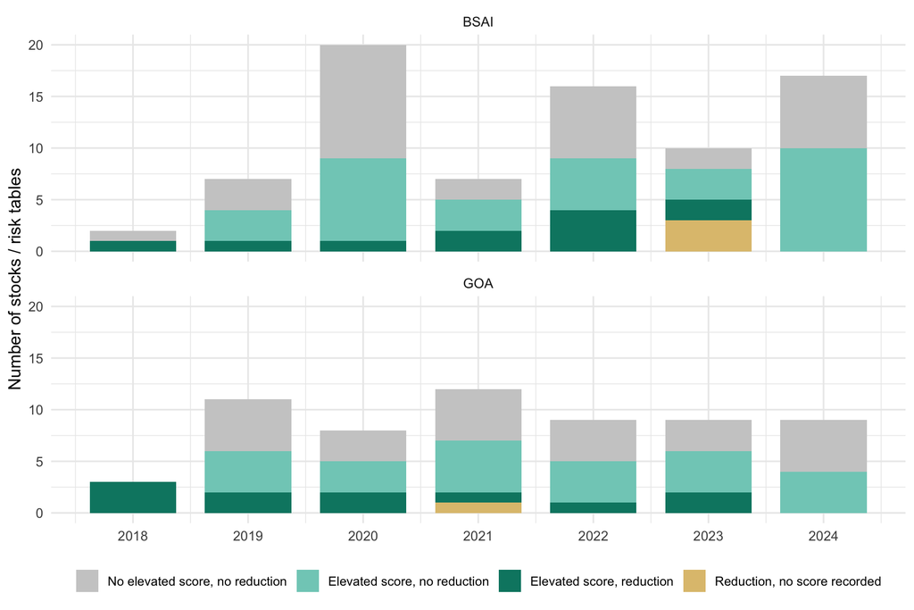

Figure 1: Annual risk-table status by region, separating stocks without elevated scores, stocks with elevated scores but no SSC reduction, stocks with elevated scores and an SSC reduction, and reductions where no risk-table score was recorded in the extracted score table.

```r
risk_status <- read_csv(
  "groundfish_risk_table_scores.csv",
  show_col_types = FALSE
) |>
  mutate(
    max_score_num = suppressWarnings(as.numeric(max_score)),
    ssc_red_num = suppressWarnings(as.numeric(ssc_recommended_reduction)),
    has_table = !is.na(max_score_num),
    has_reduction = !is.na(ssc_red_num) & ssc_red_num > 0,
    status = case_when(
      has_table & max_score_num <= 1 & !has_reduction ~
        "No elevated score, no reduction",
      has_table & max_score_num > 1 & !has_reduction ~
        "Elevated score, no reduction",
      has_table & max_score_num > 1 & has_reduction ~
        "Elevated score, reduction",
      !has_table & has_reduction ~
        "Reduction, no score recorded",
      TRUE ~ NA_character_
    ),
    status = factor(
      status,
      levels = c(
        "No elevated score, no reduction",
        "Elevated score, no reduction",
        "Elevated score, reduction",
        "Reduction, no score recorded"
      )
    )
  ) |>
  filter(!is.na(status)) |>
  count(region, year, status)

ggplot(risk_status, aes(x = year, y = n, fill = status)) +
  geom_col(width = 0.75) +
  facet_wrap(~ region, ncol = 1) +
  scale_x_continuous(breaks = 2018:2024) +
  scale_fill_manual(
    values = c(
      "No elevated score, no reduction" = "grey80",
      "Elevated score, no reduction" = "#80cdc1",
      "Elevated score, reduction" = "#018571",
      "Reduction, no score recorded" = "#dfc27d"
    )
  ) +
  labs(
    x = NULL,
    y = "Number of stocks / risk tables",
    fill = NULL
  ) +
  theme_minimal(base_size = 12) +
  theme(
    legend.position = "bottom",
    legend.text = element_text(size = 9)
  )
```

## Modeling historical patterns of ABC reductions below the maximum permissible

Before the risk table was formalized, Thompson ((Thompson 2019)) conducted an analysis for the NPFMC that asked a related question: could historical BSAI and GOA Groundfish Plan Team recommendations to set ABC below the maximum permissible level be reverse-engineered into transparent decision rules? He covered 2003-2017 and identified 76 instances in which the Plan Teams recommended ABC below `maxABC`, or about five instances per year.

The raw historical record was qualitative. For each reduction, the Plan Teams usually provided one or more reasons, and Thompson condensed 122 unique stated reasons into 66 initial binary variables. Because many reasons occurred together and made the design matrix singular, the variables were progressively combined into 52 and then 32 final “Round 3” variables. The response was the proportional reduction from `maxABC`, transformed with a symmetric logit-style mapping,

$$\log\left(\frac{1 + y_i}{1 - y_i}\right),$$

where $y_i$ is the proportional ABC reduction for instance $i$.

The first model used ordinary least squares on the transformed response, but some coefficients were negative. Thompson then fit a constrained version with nonnegative coefficients so that any applicable reason would imply either no reduction or a downward adjustment from `maxABC`, never an upward adjustment. Both models fit the historical reductions similarly well after transformation back to the natural scale, with $R^2$ values of about 0.83 for the unconstrained model and 0.82 for the constrained model (Thompson 2019).

The constrained model is useful here because it shows an earlier attempt to translate qualitative concerns into a quantitative ABC buffer. Several variables implied little or no univariate reduction once paired historical patterns were accounted for, while others implied substantial reductions when considered alone. Examples from the constrained model are shown in Table 2.

```r
tribble(
  ~reason, ~beta, ~univariate_reduction,
  "Projected biomass decline", 0.21, 0.10,
  "Long-term poor recruitment", 0.22, 0.11,
  "Dorn's buffer", 0.23, 0.11,
  "Uncertain recruitment estimates, including recent large estimates", 0.40, 0.20,
  "Model uncertainty", 0.43, 0.21,
  "Uncertainty surrounding M and Q", 0.60, 0.29,
  "Low or long-term declining biomass", 0.82, 0.39,
  "Large survey CV", 0.91, 0.43,
  "No new survey", 1.81, 0.72
) |>
  mutate(
    beta = round(beta, 2),
    `Univariate reduction (%)` = round(100 * univariate_reduction)
  ) |>
  select(
    Reason = reason,
    `Constrained beta` = beta,
    `Univariate reduction (%)`
  ) |>
  kable()
```

Table 2: Selected constrained-model coefficients and implied univariate ABC reductions from Thompson’s historical ABC reduction working paper.

| Reason | Constrained beta | Univariate reduction (%) |
| --- | --- | --- |
| Projected biomass decline | 0.21 | 10 |
| Long-term poor recruitment | 0.22 | 11 |
| Dorn’s buffer | 0.23 | 11 |
| Uncertain recruitment estimates, including recent large estimates | 0.40 | 20 |
| Model uncertainty | 0.43 | 21 |
| Uncertainty surrounding M and Q | 0.60 | 29 |
| Low or long-term declining biomass | 0.82 | 39 |
| Large survey CV | 0.91 | 43 |
| No new survey | 1.81 | 72 |

That working paper also flagged important limitations that carry over to any analysis of risk-table reductions. The historical reasons were not collected from a prospective checklist; they were usually articulated after an author or Plan Team had already become concerned that a reduction might be warranted. The variable consolidation was therefore partly subjective, and a zero coefficient did not necessarily mean a concern was unimportant. It meant only that the concern did not add explanatory power beyond the other concerns with which it had historically appeared (Thompson 2019).

The current analysis differs in two ways. First, it uses the formal risk table scores rather than the older ad hoc reason codes. Second, it focuses on final SSC reductions rather than Plan Team recommendations. The connection is that both exercises treat ABC reductions as historically observable decisions that can be modeled descriptively, while recognizing that the fitted relationships are not automatic decision rules.

## Thompson’s link between risk and ABC reductions

Further efforts to quantify translating authors’ risk scores to merit reductions from maximum permissible ABC values are shown in Thompson’s Appendix 2.6 in the 2020 EBS Pacific cod assessment (Thompson et al. 2020) proposed a direct probability link between the risk table and the reduction from maximum permissible ABC. The currency is the probability that `maxABC` exceeds the true-but-unknown OFL. The usual assessment uncertainty gives a baseline probability, $P_0$, and the risk table adds extra probability from concerns that are not already represented in the assessment model.

For each risk category $j$, Thompson first maps the assigned risk level and an within-level fraction, $\Delta_j$, to a conditional probability $P_{\mathrm{cond},j}$. With four risk levels, the probability intervals are: level 1 from $P_0$ to 0.5, level 2 from 0.5 to 2/3, level 3 from 2/3 to 5/6, and level 4 from 5/6 to 1.0. The marginal category probabilities are then combined as

$$P = 1 - (1 - P_0) \prod_j (1 - p_j),$$

where $P$ is the joint probability that `maxABC` exceeds true OFL after accounting for all risk categories. The probability-equivalent value of `maxABC` is then

$$maxABC_{PE} = cdf^{-1}(P).$$

The final buffer follows from the ratio $OFL / maxABC_{PE}$. If $maxABC_{PE}$ is greater than OFL, ABC is reduced by that ratio; otherwise ABC remains at `maxABC`.

Because the risk table changed through time, the applied calculation below uses three risk levels throughout, matching the current normal, increased, and extreme scoring. The number of categories remains year-specific: the 2018 trial-year calculations use three categories because the fishery-informed category had not yet been added, while later calculations use four categories.

Figure 2 gives a first illustration of the mechanism by reducing the four-category risk table to two simple dimensions: the number of elevated categories and the common three-level risk score assigned to those elevated categories. The panels show how the retained fraction of maximum permissible ABC changes as OFL uncertainty changes, with the within-level fraction fixed at $\Delta = 0.5$. This illustration uses the four-category, three-level structure used from 2023 onward; the applied table below uses the same three-level structure but switches the number of categories by year.

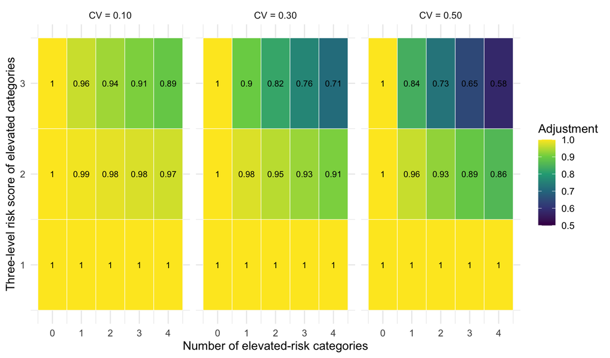

Figure 2: Illustrative adjustment under Thompson’s probability link, summarized by the number of elevated categories and the common three-level risk score assigned to those categories. Delta is fixed at 0.5, OFL is normalized to 1, and panels vary the OFL CV. ABC equals the adjustment multiplied by maxABC.

```r
thompson_p0 <- 0.49
thompson_nlev <- 3
thompson_ncat <- 4
thompson_cv <- 0.30
thompson_sigma <- sqrt(log1p(thompson_cv^2))

thompson_bounds_for_nlev <- function(nlev) {
  tibble(level = 1:nlev) |>
    mutate(
      p_upper = (level + nlev - 2) / (2 * (nlev - 1)),
      p_lower = if_else(level == 1, thompson_p0, lag(p_upper))
    )
}

thompson_bounds <- thompson_bounds_for_nlev(thompson_nlev)

level_to_p_cond <- function(level, delta = 0.5, nlev = thompson_nlev) {
  bounds <- thompson_bounds_for_nlev(nlev) |>
    filter(.data$level == .env$level)
  bounds$p_lower + delta * (bounds$p_upper - bounds$p_lower)
}

p_cond_to_marginal <- function(p_cond, ncat = thompson_ncat) {
  1 - ((1 - p_cond) / (1 - thompson_p0))^(1 / ncat)
}

joint_p <- function(pj) {
  1 - (1 - thompson_p0) * prod(1 - pj)
}

abc_retained <- function(p, cv = thompson_cv) {
  maxABC_pe_to_OFL <- qlnorm(
    p,
    meanlog = 0,
    sdlog = sqrt(log1p(cv^2))
  )
  pmin(1, 1 / maxABC_pe_to_OFL)
}

thompson_heatmap <- crossing(
  n_high = 0:thompson_ncat,
  high_level = 1:thompson_nlev,
  delta = 0.5,
  cv = c(0.10, 0.30, 0.50)
) |>
  rowwise() |>
  mutate(
    levels = list(c(rep(high_level, n_high),
                    rep(1, thompson_ncat - n_high))),
    p_cond = list(map_dbl(levels, level_to_p_cond, delta = delta)),
    pj = list(map_dbl(p_cond, p_cond_to_marginal)),
    thompson_joint_p = joint_p(pj),
    ABC_over_maxABC = abc_retained(thompson_joint_p, cv = cv)
  ) |>
  ungroup() |>
  mutate(cv = factor(cv, levels = c(0.10, 0.30, 0.50),
                     labels = c("CV = 0.10", "CV = 0.30", "CV = 0.50")))

ggplot(thompson_heatmap,
       aes(x = n_high, y = high_level, fill = ABC_over_maxABC)) +
  geom_tile(color = "white") +
  geom_text(aes(label = round(ABC_over_maxABC, 2)), size = 3) +
  facet_wrap(~ cv) +
  scale_fill_viridis_c(
    limits = c(0.5, 1),
    name = "Adjustment"
  ) +
  scale_x_continuous(breaks = 0:thompson_ncat) +
  scale_y_continuous(breaks = 1:thompson_nlev) +
  labs(
    x = "Number of elevated-risk categories",
    y = "Three-level risk score of elevated categories"
  ) +
  theme_minimal(base_size = 12)
```

The first table below revisits the values Thompson applied conceptually. The absolute value of $maxABC_{PE}$ depends on the OFL uncertainty distribution in the assessment. For comparability, Table 3 normalizes OFL to 1, uses a lognormal uncertainty distribution, sets $P_0 = 0.49$, and uses a CV of 0.30. The key column is therefore $maxABC_{PE}/OFL$, not an assessment-specific tonnage. The CV can be changed in the code chunk if a specific stock’s OFL uncertainty is available.

```r
thompson_bounds_midpoint <- thompson_bounds |>
  mutate(
    delta_midpoint = 0.5,
    p_cond_midpoint = p_lower + delta_midpoint * (p_upper - p_lower),
    maxABC_pe_to_OFL = qlnorm(
      p_cond_midpoint,
      meanlog = 0,
      sdlog = thompson_sigma
    )
  )

thompson_bounds_midpoint |>
  transmute(
    `Risk level` = level,
    `P lower` = round(p_lower, 3),
    `P upper` = round(p_upper, 3),
    `P midpoint` = round(p_cond_midpoint, 3),
    `maxABC_PE / OFL` = round(maxABC_pe_to_OFL, 3)
  ) |>
  kable()
```

Table 3: Thompson risk-level probability intervals and probability-equivalent maxABC values under an illustrative lognormal OFL distribution.

| Risk level | P lower | P upper | P midpoint | maxABC_PE / OFL |
| --- | --- | --- | --- | --- |
| 1 | 0.49 | 0.50 | 0.495 | 0.996 |
| 2 | 0.50 | 0.75 | 0.625 | 1.098 |
| 3 | 0.75 | 1.00 | 0.875 | 1.402 |

To apply the same logic to the historical score combinations in this report, Table 4 uses the year-appropriate number of categories, uses three risk levels for all years, treats scores of 0 as normal level 1, and sets the within-level fraction to $\Delta = 0.9$. This is not a reconstruction of the SSC’s calculation, because the actual within-level $\Delta$ values and stock-specific OFL uncertainty distributions are not in the summary table. It is a transparent benchmark showing the probability-equivalent `maxABC` implied by Thompson’s mapping for the observed score combinations.

```r
thompson_applied_delta <- 0.9

year_settings <- function(year) {
  tibble(
    ncat = if_else(year == 2018, 3L, 4L),
    nlev = 3L,
    scoring_era = case_when(
      year == 2018 ~ "2018: 3 categories, 3 levels",
      TRUE ~ "2019+: 4 categories, 3 levels"
    )
  )
}

score_to_level <- function(score, nlev) {
  pmin(pmax(if_else(score == 0, 1, score), 1), nlev)
}

row_thompson <- function(A, P, E, F, year, delta = 0.5,
                         cv = thompson_cv) {
  settings <- year_settings(year)
  scores <- if (settings$ncat == 3L) {
    c(A, P, E)
  } else {
    c(A, P, E, F)
  }
  levels <- score_to_level(scores, settings$nlev)
  p_cond <- map_dbl(levels, level_to_p_cond,
                    delta = delta, nlev = settings$nlev)
  pj <- map_dbl(p_cond, p_cond_to_marginal, ncat = settings$ncat)
  p <- joint_p(pj)
  maxABC_pe_to_OFL <- qlnorm(
    p,
    meanlog = 0,
    sdlog = sqrt(log1p(cv^2))
  )
  tibble(
    ncat = settings$ncat,
    nlev = settings$nlev,
    scoring_era = settings$scoring_era,
    thompson_joint_p = p,
    maxABC_pe_to_OFL = maxABC_pe_to_OFL,
    thompson_abc_to_maxABC = pmin(1, 1 / maxABC_pe_to_OFL),
    thompson_pct_reduction = 100 * (1 - thompson_abc_to_maxABC)
  )
}

thompson_applied <- dat |>
  mutate(thompson = pmap(
    list(A, P, E, F, year),
    row_thompson,
    delta = thompson_applied_delta
  )) |>
  unnest(thompson)

thompson_applied |>
  transmute(
    Stock = stock,
    Year = year,
    A, P, E, F,
    `Scoring era` = scoring_era,
    ncat,
    nlev,
    `Observed SSC reduction (%)` = pct_red,
    `Joint P` = round(thompson_joint_p, 3),
    `maxABC_PE / OFL` = round(maxABC_pe_to_OFL, 3),
    `Thompson reduction (%)` = round(thompson_pct_reduction, 1)
  ) |>
  arrange(desc(`maxABC_PE / OFL`), Stock, Year) |>
  kable()
```

Table 4: Illustrative application of Thompson’s probability mapping to observed score combinations using three risk levels and within-level delta = 0.9. OFL is normalized to 1 and CV is set to 0.30.

| Stock | Year | A | P | E | F | Scoring era | ncat | nlev | Observed SSC reduction (%) | Joint P | maxABC_PE / OFL | Thompson reduction (%) |
| --- | --- | --- | --- | --- | --- | --- | --- | --- | --- | --- | --- | --- |
| AK Sablefish | 2020 | 3 | 3 | 2 | 3 | 2019+: 4 categories, 3 levels | 4 | 3 | 44 | 0.954 | 1.642 | 39.1 |
| AK Sablefish | 2019 | 2 | 3 | 2 | 3 | 2019+: 4 categories, 3 levels | 4 | 3 | 50 | 0.917 | 1.502 | 33.4 |
| AK Sablefish | 2018 | 2 | 4 | 2 | 0 | 2018: 3 categories, 3 levels | 3 | 3 | 45 | 0.876 | 1.404 | 28.8 |
| BSAI Blackspotted/Rougheye RF | 2022 | 3 | 2 | 0 | 2 | 2019+: 4 categories, 3 levels | 4 | 3 | 11 | 0.825 | 1.315 | 24.0 |
| BSAI Greenland turbot | 2024 | 3 | 2 | 2 | 0 | 2019+: 4 categories, 3 levels | 4 | 3 | 25 | 0.825 | 1.315 | 24.0 |
| BSAI Sharks | 2022 | 3 | 2 | 0 | 0 | 2019+: 4 categories, 3 levels | 4 | 3 | 13 | 0.796 | 1.275 | 21.6 |
| BSAI Northern rock sole | 2022 | 3 | 0 | 0 | 0 | 2019+: 4 categories, 3 levels | 4 | 3 | 23 | 0.763 | 1.234 | 19.0 |
| EBS Pollock | 2019 | 0 | 2 | 2 | 2 | 2019+: 4 categories, 3 levels | 4 | 3 | 43 | 0.681 | 1.148 | 12.9 |
| EBS Pollock | 2021 | 2 | 0 | 2 | 2 | 2019+: 4 categories, 3 levels | 4 | 3 | 11 | 0.681 | 1.148 | 12.9 |
| GOA Demersal shelf rockfish | 2021 | 2 | 2 | 0 | 2 | 2019+: 4 categories, 3 levels | 4 | 3 | 22 | 0.681 | 1.148 | 12.9 |
| GOA Demersal shelf rockfish | 2022 | 2 | 2 | 0 | 2 | 2019+: 4 categories, 3 levels | 4 | 3 | 15 | 0.681 | 1.148 | 12.9 |
| EBS Pollock | 2018 | 0 | 2 | 2 | 0 | 2018: 3 categories, 3 levels | 3 | 3 | 30 | 0.664 | 1.132 | 11.7 |
| AI Pacific cod | 2023 | 0 | 2 | 2 | 0 | 2019+: 4 categories, 3 levels | 4 | 3 | 10 | 0.629 | 1.101 | 9.2 |
| BSAI Yellowfin sole | 2021 | 0 | 2 | 2 | 0 | 2019+: 4 categories, 3 levels | 4 | 3 | 24 | 0.629 | 1.101 | 9.2 |
| EBS Pollock | 2020 | 0 | 0 | 2 | 2 | 2019+: 4 categories, 3 levels | 4 | 3 | 30 | 0.629 | 1.101 | 9.2 |
| GOA Rougheye/Blackspotted RF | 2023 | 2 | 2 | 0 | 0 | 2019+: 4 categories, 3 levels | 4 | 3 | 20 | 0.629 | 1.101 | 9.2 |
| EBS Pacific cod | 2019 | 0 | 0 | 2 | 0 | 2019+: 4 categories, 3 levels | 4 | 3 | 3 | 0.569 | 1.052 | 5.0 |
| EBS Pollock | 2022 | 2 | 0 | 0 | 0 | 2019+: 4 categories, 3 levels | 4 | 3 | 43 | 0.569 | 1.052 | 5.0 |
| EBS Pollock | 2023 | 0 | 0 | 2 | 0 | 2019+: 4 categories, 3 levels | 4 | 3 | 18 | 0.569 | 1.052 | 5.0 |
| GOA Dusky Rockfish | 2020 | 2 | 0 | 0 | 0 | 2019+: 4 categories, 3 levels | 4 | 3 | 24 | 0.569 | 1.052 | 5.0 |
| GOA Pollock | 2023 | 2 | 0 | 0 | 0 | 2019+: 4 categories, 3 levels | 4 | 3 | 18 | 0.569 | 1.052 | 5.0 |

Figure 3 compares the observed SSC reductions with three-level Thompson reductions across three OFL uncertainty values: CV = 0.10, 0.30, and 0.50. The within-level fraction is fixed at $\Delta = 0.9$, matching Table 4. Points above the 1:1 line indicate cases where the illustrative Thompson calculation would imply a larger reduction than the observed SSC reduction; points below the line indicate cases where it would imply a smaller reduction.

```r
thompson_cv_grid <- dat |>
  crossing(
    delta = thompson_applied_delta,
    cv = c(0.10, 0.30, 0.50)
  ) |>
  mutate(thompson = pmap(
    list(A, P, E, F, year, delta, cv),
    row_thompson
  )) |>
  unnest(thompson) |>
  mutate(cv = factor(cv, levels = c(0.10, 0.30, 0.50),
                     labels = c("CV = 0.10", "CV = 0.30", "CV = 0.50")),
         hover = paste0(
           "Stock: ", stock,
           "<br>Year: ", year,
           "<br>OFL CV: ", cv,
           "<br>Observed SSC reduction: ", round(pct_red, 1), "%",
           "<br>Thompson reduction: ", round(thompson_pct_reduction, 1), "%"
         ))

p_thompson_observed <- ggplot(
  thompson_cv_grid,
  aes(
    x = pct_red,
    y = thompson_pct_reduction,
    color = factor(year),
    shape = cv,
    text = hover
  )
) +
  geom_abline(slope = 1, intercept = 0,
              linetype = "dashed", color = "grey55") +
  geom_point(size = 3, alpha = 0.9) +
  scale_color_viridis_d(name = "Year") +
  labs(
    x = "Observed SSC reduction from maxABC (%)",
    y = "Thompson reduction from maxABC (%)",
    color = "Year",
    shape = "OFL CV"
  ) +
  coord_equal(xlim = c(0, 75), ylim = c(0, 75)) +
  theme(legend.position = "none")

ggplotly(p_thompson_observed, tooltip = "text")
```

[interactive chart not shown]

Figure 3: Observed SSC reduction compared with the illustrative three-level Thompson reduction. Colors show years and shapes show OFL CV, with delta fixed at 0.9.

In plain language, Thompson’s method turns the risk table into a probability meter and then into a catch dial. The starting point is the assessment model’s baseline probability, $P_0$, that `maxABC` would exceed the true OFL. The risk table then adds the concerns that are not already captured by the model: assessment issues, population dynamics, ecosystem signals, and fishery information. Each category is assigned a risk level, optionally fine-tuned within that level with $\Delta$, and those category risks are combined into one overall probability, $P$.

The decision rule is simple. If $P \leq 0.5$, the probability of overfishing is treated as acceptable and ABC remains at `maxABC`. If $P > 0.5$, the probability is too high and ABC is scaled down. Higher values of $P$ imply a larger gap between `maxABC` and the probability-equivalent `maxABC`, so the resulting ABC reduction gets larger.

The intuition is: few low-risk scores are a green light for full catch; some moderate risks are a yellow light for a smaller cut; many high risks are a red light for a larger cut. In one line, more risk means a higher chance of overfishing, which means a lower allowed catch.

## Exploratory analyses

The exploratory displays in Figure 4, Figure 5, Figure 6, and Figure 7 are intended to answer a simple question before formal modeling begins: do the risk table scores contain visible signal about the size of the final SSC reduction, and if so, what kind of signal is it? Together these figures separate severity, breadth, category-specific effects, and correlation structure.

### Reduction vs. total risk score

Figure 4 motivates the most basic candidate model by asking whether larger summed scores are generally associated with larger reductions. If the total score were carrying most of the information in the risk table, a clear monotonic relationship would be expected here.

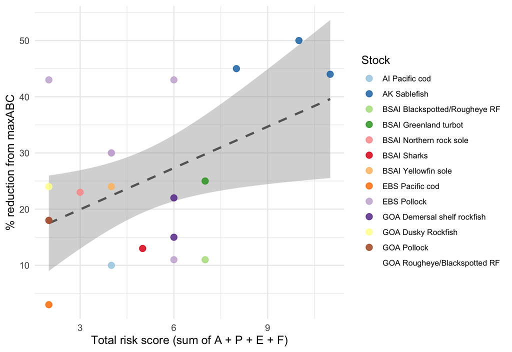

Figure 4: Percent reduction from maxABC vs. total risk score (sum of elevated category scores). Points are colored by stock. The dashed line is a simple linear fit.

```r
ggplot(dat, aes(x = total_score, y = pct_red)) +
geom_smooth(method = "lm", formula = y ~ x,
              se = TRUE, color = "grey40", linetype = "dashed") +
  geom_point(aes(color = stock), size = 3, alpha = 0.85) +
  scale_color_brewer(palette = "Paired", name = "Stock") +
  labs(x = "Total risk score (sum of A + P + E + F)",
       y = "% reduction from maxABC") +
  theme(legend.position = "right",
        legend.text = element_text(size = 9))
```

The broad spread around the fitted line in Figure 4 immediately suggests that the total score alone will be an incomplete summary of the SSC decision process, even if it captures some central tendency.

### Reduction vs. number of elevated categories

Figure 5 shifts attention from severity to breadth. The goal is to see whether reductions tend to increase as more categories are flagged, even when the exact numerical scores differ across stocks and years.

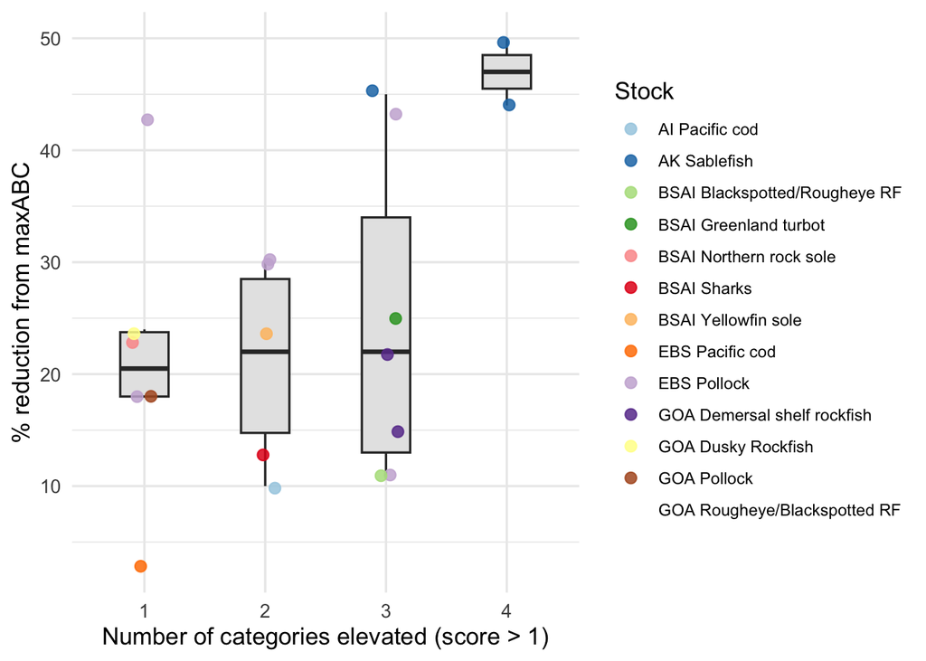

Figure 5: Percent reduction from maxABC vs. number of risk table categories scored above 1.

```r
ggplot(dat, aes(x = factor(n_elevated), y = pct_red)) +
  geom_boxplot(width = 0.4, outlier.shape = NA, fill = "grey90") +
  geom_jitter(aes(color = stock), width = 0.12, size = 2.5, alpha = 0.85) +
  scale_color_brewer(palette = "Paired", name = "Stock") +
  labs(x = "Number of categories elevated (score > 1)",
       y = "% reduction from maxABC") +
  theme(legend.position = "right",
        legend.text = element_text(size = 9))
```

This view is useful because a stock with several modest concerns may be treated differently from a stock with one isolated but severe concern, and Figure 5 makes that contrast easier to see than a summed score alone.

### Reduction by individual category score

Figure 6 provides the main category-by-category context for the later coefficient models. Rather than collapsing the table to a single summary metric, it shows how the observed reductions vary with score level within each of the four risk dimensions.

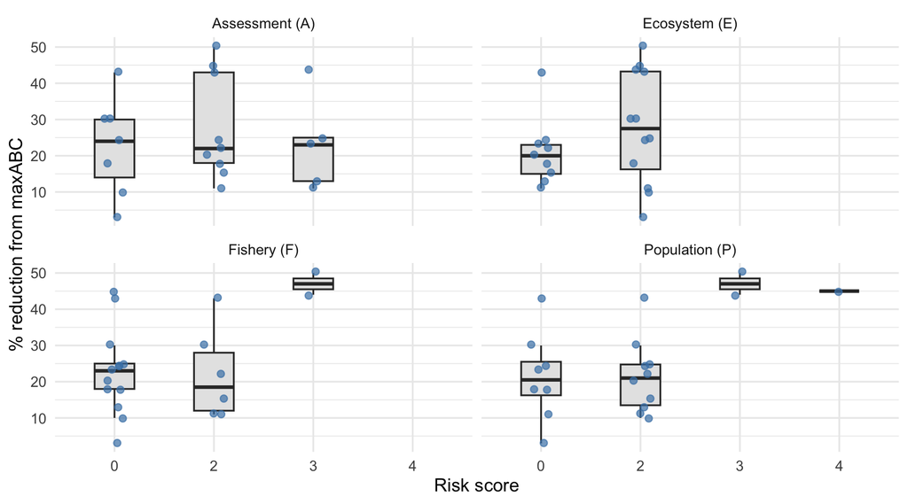

Figure 6: Percent reduction from maxABC broken out by score level within each risk table category. Points are jittered horizontally.

```r
dat |>
  pivot_longer(cols = c(A, P, E, F), names_to = "category", values_to = "score") |>
  mutate(category = recode(category,
    A = "Assessment (A)", P = "Population (P)",
    E = "Ecosystem (E)",  F = "Fishery (F)")) |>
  ggplot(aes(x = factor(score), y = pct_red)) +
  geom_boxplot(width = 0.4, outlier.shape = NA, fill = "grey90") +
  geom_jitter(width = 0.1, size = 2, alpha = 0.7, color = "steelblue") +
  facet_wrap(~ category) +
  labs(x = "Risk score", y = "% reduction from maxABC")
```

This comparison helps assess whether some dimensions appear to matter more than others. In particular, it previews whether population, ecosystem, or assessment-related concerns tend to align more consistently with larger reductions.

### Correlation matrix of predictors

Figure 7 is included as diagnostic context for model specification. The purpose is not substantive on its own, but to show where predictors move together and where they contain distinct information.

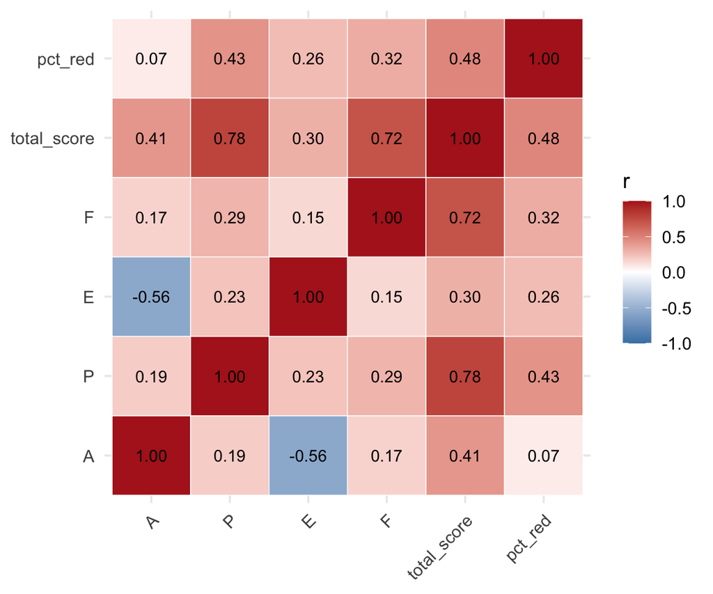

Figure 7: Pairwise correlation among risk score predictors and the percent reduction.

```r
cor_mat <- dat |>
  select(A, P, E, F, total_score, pct_red) |>
  cor()

cor_long <- as.data.frame(as.table(cor_mat)) |>
  rename(var1 = Var1, var2 = Var2, r = Freq)

ggplot(cor_long, aes(var1, var2, fill = r)) +
  geom_tile(color = "white") +
  geom_text(aes(label = sprintf("%.2f", r)), size = 3.5) +
  scale_fill_gradient2(low = "steelblue", mid = "white", high = "firebrick",
                       midpoint = 0, limits = c(-1, 1), name = "r") +
  labs(x = NULL, y = NULL) +
  theme(axis.text.x = element_text(angle = 45, hjust = 1))
```

The correlation structure in Figure 7 informs whether a more aggregated model is reasonable and helps interpret coefficient instability in models that include all category scores simultaneously.

### Models

The frequentist models below provide progressively richer summaries of the relationship between risk table scores and SSC reductions. A Bayesian mixed-effects model is then added to account explicitly for repeated observations from the same stock through partial pooling.

We consider four candidate models, ranging from simple to structured.

#### Model 1: OLS on total score

A baseline linear model treating the sum of scores as the sole predictor is provided in Model 1. It shows the simplest aggregate relationship with the estimated total-score slope 2.46 percentage points per score unit, with adjusted $R^2$ = 0.19. This is useful as a baseline, but the fit indicates that total score alone explains only a limited share of the observed variation in SSC reductions.

```r
lm_coef_table(m1) |>
  gt() |>
  fmt_number(columns = c(Estimate, `Std. error`, `t value`), decimals = 2) |>
  tab_source_note(
    source_note = md(paste0(
      "Model fit: N = ", nobs(m1),
      "; adjusted R^2 = ", round(summary(m1)$adj.r.squared, 2),
      "; AIC = ", round(AIC(m1), 1), "."
    ))
  )
```

Table 5: Model 1 coefficient summary: OLS reduction model using total risk score.

| Term | Estimate | Std. error | t value | p value |
| --- | --- | --- | --- | --- |
| (Intercept) | 12.58 | 5.78 | 2.17 | 0.042 |
| total_score | 2.46 | 1.03 | 2.38 | 0.028 |

Model fit: N = 21; adjusted R^2 = 0.19; AIC = 167.9.

#### Model 2: OLS with individual category scores

Model 2 allows each risk dimension to carry different weight by separating the risk table into its four components. The population dynamics coefficient is 3.25, compared with 1.19 for assessment, 2.92 for ecosystem, and 2.11 for fishery-informed concerns. This model is more interpretable than Model 1 because it allows different types of risk to have different associations with reductions, but the small sample means the coefficient uncertainty remains important.

```r
lm_coef_table(m2) |>
  gt() |>
  fmt_number(columns = c(Estimate, `Std. error`, `t value`), decimals = 2) |>
  tab_source_note(
    source_note = md(paste0(
      "Model fit: N = ", nobs(m2),
      "; adjusted R^2 = ", round(summary(m2)$adj.r.squared, 2),
      "; AIC = ", round(AIC(m2), 1), "."
    ))
  )
```

Table 6: Model 2 coefficient summary: OLS reduction model using individual risk-category scores.

| Term | Estimate | Std. error | t value | p value |
| --- | --- | --- | --- | --- |
| (Intercept) | 13.20 | 8.00 | 1.65 | 0.118 |
| A | 1.19 | 3.23 | 0.37 | 0.717 |
| P | 3.25 | 2.62 | 1.24 | 0.233 |
| E | 2.92 | 3.86 | 0.76 | 0.461 |
| F | 2.11 | 2.70 | 0.78 | 0.445 |

Model fit: N = 21; adjusted R^2 = 0.07; AIC = 173.3.

#### Model 3: Beta regression on individual scores

Beta regression is the natural choice for a bounded proportional response, and Model 3 keeps the category-level structure while respecting that proportional reductions are bounded between zero and one. Coefficients are on the logit scale, so positive values indicate higher expected proportional reductions after accounting for the other categories. The pseudo $R^2$ is 0.19, which makes this a useful descriptive model for direction and relative strength rather than a precise prediction rule.

```r
betareg_coef_table(m3) |>
  gt(groupname_col = "Component") |>
  fmt_number(columns = c(Estimate, `Std. error`, `z value`), decimals = 2) |>
  tab_source_note(
    source_note = md(paste0(
      "Model fit: N = ", nobs(m3),
      "; pseudo R^2 = ", round(m3$pseudo.r.squared, 2),
      "; AIC = ", round(AIC(m3), 1), "."
    ))
  )
```

Table 7: Model 3 coefficient summary: beta regression using individual risk-category scores.

| Term | Estimate | Std. error | z value | p value |
| --- | --- | --- | --- | --- |
| Mean |  |  |  |  |
| (Intercept) | −1.79 | 0.37 | −4.78 | <0.001 |
| A | 0.06 | 0.15 | 0.39 | 0.694 |
| P | 0.21 | 0.12 | 1.71 | 0.087 |
| E | 0.13 | 0.18 | 0.76 | 0.445 |
| F | 0.11 | 0.12 | 0.89 | 0.373 |
| Precision |  |  |  |  |
| (phi) | 13.23 | 4.00 | 3.31 | <0.001 |

Model fit: N = 21; pseudo R^2 = 0.19; AIC = -22.2.

#### Model 4: Beta regression with total score + number elevated

Model 4 is a parsimonious alternative that separates severity, measured as the total score, from breadth, measured as how many categories are flagged. It asks whether the overall severity of the scores and the number of flagged categories carry distinct information. The total-score coefficient is 0.31 on the logit scale, while the number-elevated coefficient is -0.49. This provides a compact alternative to the category-level model, but it also collapses information about which specific risk dimension is driving the concern.

```r
betareg_coef_table(m4) |>
  gt(groupname_col = "Component") |>
  fmt_number(columns = c(Estimate, `Std. error`, `z value`), decimals = 2) |>
  tab_source_note(
    source_note = md(paste0(
      "Model fit: N = ", nobs(m4),
      "; pseudo R^2 = ", round(m4$pseudo.r.squared, 2),
      "; AIC = ", round(AIC(m4), 1), "."
    ))
  )
```

Table 8: Model 4 coefficient summary: beta regression using total score and number of elevated categories.

| Term | Estimate | Std. error | z value | p value |
| --- | --- | --- | --- | --- |
| Mean |  |  |  |  |
| (Intercept) | −1.59 | 0.37 | −4.34 | <0.001 |
| total_score | 0.31 | 0.19 | 1.66 | 0.097 |
| n_elevated | −0.49 | 0.50 | −0.98 | 0.328 |
| Precision |  |  |  |  |
| (phi) | 13.25 | 4.00 | 3.31 | <0.001 |

Model fit: N = 21; pseudo R^2 = 0.21; AIC = -26.4.

#### Sensitivity: harmonized score scale

The main regression models above use the scores as recorded in the historical risk table summary. Because the scoring scale changed in 2023, the sensitivity models below harmonize 2023+ scores to the earlier four-level scale before fitting the same broad model forms. Specifically, current level 2 is treated as old level 3 and current level 3 is treated as old level 4. This adjustment does not change whether a category is elevated, but it does change the severity assigned to recent elevated scores.

The harmonized fits should be read as a sensitivity analysis rather than a replacement for the raw-score models. They ask whether the main conclusions are sensitive to treating the 2023+ three-level scores as compressed versions of the earlier four-level scores. If the raw and harmonized rows give similar AIC and pseudo-$R^2$ values, the broad conclusions are not being driven mainly by the post-2023 scale change; larger differences would indicate that the score compression matters for the fitted relationship.

```r
m2_harmonized <- lm(
  pct_red ~ A_harmonized + P_harmonized + E_harmonized + F_harmonized,
  data = dat
)

m3_harmonized <- betareg(
  pct_red_prop ~ A_harmonized + P_harmonized +
    E_harmonized + F_harmonized,
  data = dat
)

m4_harmonized <- betareg(
  pct_red_prop ~ total_score_harmonized + n_elevated_harmonized,
  data = dat
)

harmonized_compare <- tribble(
  ~model, ~score_scale, ~description, ~AIC, ~R2,
  "M2", "Raw", "OLS ~ A + P + E + F",
    AIC(m2), summary(m2)$adj.r.squared,
  "M2h", "Harmonized", "OLS ~ A + P + E + F",
    AIC(m2_harmonized), summary(m2_harmonized)$adj.r.squared,
  "M3", "Raw", "Beta ~ A + P + E + F",
    AIC(m3), m3$pseudo.r.squared,
  "M3h", "Harmonized", "Beta ~ A + P + E + F",
    AIC(m3_harmonized), m3_harmonized$pseudo.r.squared,
  "M4", "Raw", "Beta ~ total + n_elevated",
    AIC(m4), m4$pseudo.r.squared,
  "M4h", "Harmonized", "Beta ~ total + n_elevated",
    AIC(m4_harmonized), m4_harmonized$pseudo.r.squared
)

harmonized_compare |>
  mutate(across(c(AIC, R2), ~ round(.x, 2))) |>
  rename(
    Model = model,
    `Score scale` = score_scale,
    Description = description,
    `R² / pseudo-R²` = R2
  ) |>
  gt() |>
  fmt_number(columns = c(AIC, `R² / pseudo-R²`), decimals = 2) |>
  tab_source_note(
    source_note = "Harmonized models remap 2023+ increased and extreme scores to the earlier four-level scale before fitting."
  )
```

Table 9: Sensitivity comparison using raw scores and harmonized 2023+ scores.

| Model | Score scale | Description | AIC | R² / pseudo-R² |
| --- | --- | --- | --- | --- |
| M2 | Raw | OLS ~ A + P + E + F | 173.31 | 0.07 |
| M2h | Harmonized | OLS ~ A + P + E + F | 175.03 | −0.01 |
| M3 | Raw | Beta ~ A + P + E + F | −22.21 | 0.19 |
| M3h | Harmonized | Beta ~ A + P + E + F | −20.61 | 0.16 |
| M4 | Raw | Beta ~ total + n_elevated | −26.42 | 0.21 |
| M4h | Harmonized | Beta ~ total + n_elevated | −24.14 | 0.15 |

Harmonized models remap 2023+ increased and extreme scores to the earlier four-level scale before fitting.

#### Model 5: Bayesian beta mixed-effects model

The previous models treat stock-year observations as conditionally independent. That is a strong assumption because repeated entries for the same stock may share unmeasured characteristics that affect the SSC’s choice of reduction. To address that structure, the final model uses a beta likelihood with the same four category scores as fixed effects and a stock-level random intercept.

For observation $i$ from stock $s[i]$, let $y_i$ denote the proportional reduction from maxABC. The Bayesian model is:

$$y_i \sim \text{Beta}(\mu_i \phi,\ (1 - \mu_i)\phi)
\tag{1}$$

$$\text{logit}(\mu_i) = \alpha + \beta_A A_i + \beta_P P_i + \beta_E E_i + \beta_F F_i + u_{s[i]}
\tag{2}$$

$$u_s \sim \mathcal{N}(0, \sigma_{\text{stock}}), \qquad
\sigma_{\text{stock}} > 0
\tag{3}$$

This formulation keeps the bounded-response structure of Model 3 while letting each stock deviate from the overall intercept in a partially pooled way. Weakly informative priors are used to stabilize estimation given the small sample size.

```r
intercept_prior_mean <- qlogis(mean(dat$pct_red_prop))

priors_m5 <- c(
  prior_string(
    sprintf("normal(%0.6f, 1.5)", intercept_prior_mean),
    class = "Intercept"
  ),
  prior(normal(0, 1.5), class = "b"),
  prior(exponential(1), class = "sd"),
  prior(exponential(1), class = "phi")
)

m5 <- brm(
  formula = bf(pct_red_prop ~ A + P + E + F + (1 | stock)),
  data = dat,
  family = Beta(link = "logit"),
  prior = priors_m5,
  chains = 2,
  iter = 2000,
  warmup = 1000,
  cores = min(2, parallel::detectCores()),
  seed = 1234,
  backend = "rstan",
  control = list(adapt_delta = 0.95),
  file = "m5_brms_fit",
  file_refit = "on_change",
  refresh = 0
)
```

Table 10 summarizes the posterior for the main coefficients and the stock-level variance term. These estimates are easiest to interpret directionally: positive values indicate larger expected reductions on the logit scale, after accounting for the other scores and stock-to-stock heterogeneity.

Because the Bayesian model includes stock-level partial pooling, it is not strictly comparable to the AIC table below on the same scale. Instead, it is best read as a complementary model that asks whether the main category effects remain after allowing each stock to have its own baseline tendency toward higher or lower reductions. The stock-level standard deviation summarizes how much repeated observations differ among stocks after accounting for the four score categories; the wide posterior intervals on category effects are a useful reminder that this dataset is small for a hierarchical model.

```r
m5_post <- posterior_summary(
  m5,
  variable = c(
    "Intercept",
    "b_A", "b_P", "b_E", "b_F",
    "sd_stock__Intercept",
    "phi"
  ),
  probs = c(0.025, 0.975)
) |>
  as.data.frame() |>
  rownames_to_column("parameter") |>
  mutate(
    parameter = recode(
      parameter,
      `Intercept` = "Intercept",
      `b_A` = "Assessment (A)",
      `b_P` = "Population (P)",
      `b_E` = "Ecosystem (E)",
      `b_F` = "Fishery (F)",
      `sd_stock__Intercept` = "Stock SD",
      `phi` = "Precision (phi)"
    )
  ) |>
  rename(
    Estimate = Estimate,
    `Est. Error` = Est.Error,
    `2.5%` = Q2.5,
    `97.5%` = Q97.5
  ) |>
  mutate(across(where(is.numeric), ~ round(.x, 2)))

m5_post |>
  gt() |>
  fmt_number(
    columns = c(Estimate, `Est. Error`, `2.5%`, `97.5%`),
    decimals = 2
  ) |>
  tab_source_note(
    source_note = "Intervals are central 95% posterior intervals."
  )
```

Table 10: Posterior summaries for the Bayesian beta mixed-effects model.

| parameter | Estimate | Est. Error | 2.5% | 97.5% |
| --- | --- | --- | --- | --- |
| Intercept | −1.11 | 0.25 | −1.62 | −0.61 |
| Assessment (A) | 0.02 | 0.24 | −0.48 | 0.48 |
| Population (P) | 0.20 | 0.20 | −0.18 | 0.60 |
| Ecosystem (E) | 0.02 | 0.29 | −0.59 | 0.56 |
| Fishery (F) | 0.08 | 0.20 | −0.32 | 0.46 |
| Stock SD | 0.30 | 0.25 | 0.01 | 0.87 |
| Precision (phi) | 5.94 | 1.84 | 2.92 | 10.19 |

Intervals are central 95% posterior intervals.

#### Model comparison

Table 11 brings the four candidate models onto a common footing. The motivation is pragmatic: rather than argue for a model based only on interpretability, it compares fit statistics to show whether added structure is buying meaningful explanatory value.

Read Table 11 as a compact summary of the tradeoff between parsimony and flexibility. It indicates whether it is more useful to model the four categories separately or to collapse them into broader summaries like total score and number elevated. Lower AIC values indicate better relative support among the frequentist candidates, while the $R^2$/pseudo-$R^2$ column gives a rough sense of descriptive fit on each model’s native scale.

```r
compare <- tribble(
  ~model, ~description, ~AIC, ~R2,
  "M1", "OLS ~ total score",
    AIC(m1), summary(m1)$adj.r.squared,
  "M2", "OLS ~ A + P + E + F",
    AIC(m2), summary(m2)$adj.r.squared,
  "M3", "Beta ~ A + P + E + F",
    AIC(m3), m3$pseudo.r.squared,
  "M4", "Beta ~ total + n_elevated",
    AIC(m4), m4$pseudo.r.squared
)

compare |>
  mutate(across(c(AIC, R2), ~ round(.x, 2))) |>
  rename(
    Model = model,
    Description = description,
    `R² / pseudo-R²` = R2
  ) |>
  gt() |>
  fmt_number(columns = c(AIC, `R² / pseudo-R²`), decimals = 2)
```

Table 11: Model comparison. AIC and pseudo/adjusted R² where available.

| Model | Description | AIC | R² / pseudo-R² |
| --- | --- | --- | --- |
| M1 | OLS ~ total score | 167.94 | 0.19 |
| M2 | OLS ~ A + P + E + F | 173.31 | 0.07 |
| M3 | Beta ~ A + P + E + F | −22.21 | 0.19 |
| M4 | Beta ~ total + n_elevated | −26.42 | 0.21 |

#### Observed vs. fitted

Figure 8 provides the most direct visual model check in the report. Its purpose is to show how closely each candidate model reproduces the observed reductions across the full sample, and whether any model systematically underpredicts or overpredicts certain cases.

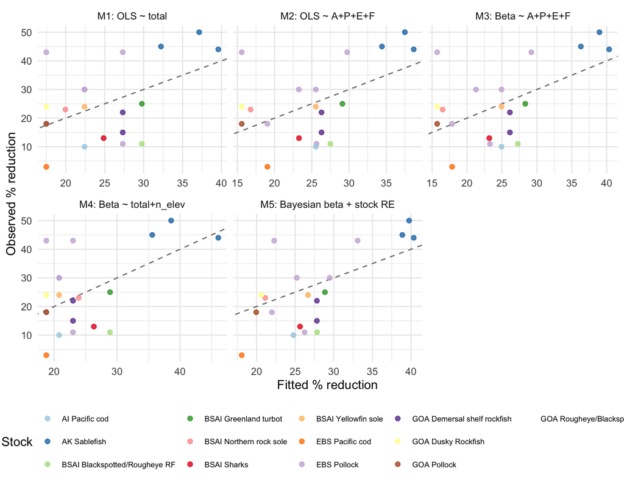

Figure 8: Observed vs. fitted reductions for the five candidate models. The 1:1 line is shown for reference.

```r
fits <- dat |>
  mutate(
    M1 = fitted(m1),
    M2 = fitted(m2),
    M3 = fitted(m3) * 100,
    M4 = fitted(m4) * 100,
    M5 = fitted(m5, summary = TRUE)[, "Estimate"] * 100
  ) |>
  pivot_longer(M1:M5, names_to = "model", values_to = "fitted") |>
  mutate(model = recode(model,
    M1 = "M1: OLS ~ total",
    M2 = "M2: OLS ~ A+P+E+F",
    M3 = "M3: Beta ~ A+P+E+F",
    M4 = "M4: Beta ~ total+n_elev",
    M5 = "M5: Bayesian beta + stock RE"))

ggplot(fits, aes(x = fitted, y = pct_red)) +
  geom_abline(slope = 1, intercept = 0, linetype = "dashed", color = "grey50") +
  geom_point(aes(color = stock), size = 2, alpha = 0.8) +
  facet_wrap(~ model, scales = "free_x") +
  scale_color_brewer(palette = "Paired", name = "Stock") +
  labs(x = "Fitted % reduction", y = "Observed % reduction") +
  theme(legend.position = "bottom",
        legend.text = element_text(size = 8))
```

Because the 1:1 line is drawn explicitly in Figure 8, departures from that line make it easier to identify which observations are structurally hard to explain regardless of model choice.

#### Coefficient effects (beta regression)

Figure 9 translates the preferred category-based beta regression into an interpretable effect display. The main motivation is to show direction, magnitude, and uncertainty for each category after accounting for the others in the same model.

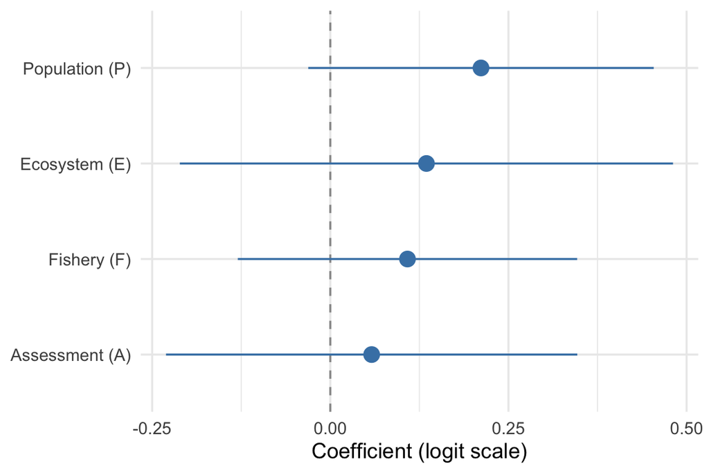

Figure 9: Estimated marginal effect of each risk score category on percent reduction (Model 3, beta regression). Points show the coefficient estimate on the logit scale; bars are 95% confidence intervals.

```r
coef_tbl <- broom::tidy(m3, conf.int = TRUE) |>
  filter(component == "mean", term != "(Intercept)") |>
  mutate(term = recode(term,
    A = "Assessment (A)", P = "Population (P)",
    E = "Ecosystem (E)",  F = "Fishery (F)"))

ggplot(coef_tbl, aes(x = estimate, y = reorder(term, estimate))) +
  geom_vline(xintercept = 0, linetype = "dashed", color = "grey60") +
  geom_pointrange(aes(xmin = conf.low, xmax = conf.high),
                  size = 0.8, color = "steelblue") +
  labs(x = "Coefficient (logit scale)", y = NULL)
```

In that sense, Figure 9 is the clearest summary of which risk dimensions are most strongly associated with larger reductions once the overlapping signal among categories is taken into account.

Figure 10 addresses model adequacy rather than fishery interpretation. The intent is to check whether the beta regression leaves obvious structure in the residuals or shows departures large enough to undermine the main inferences.

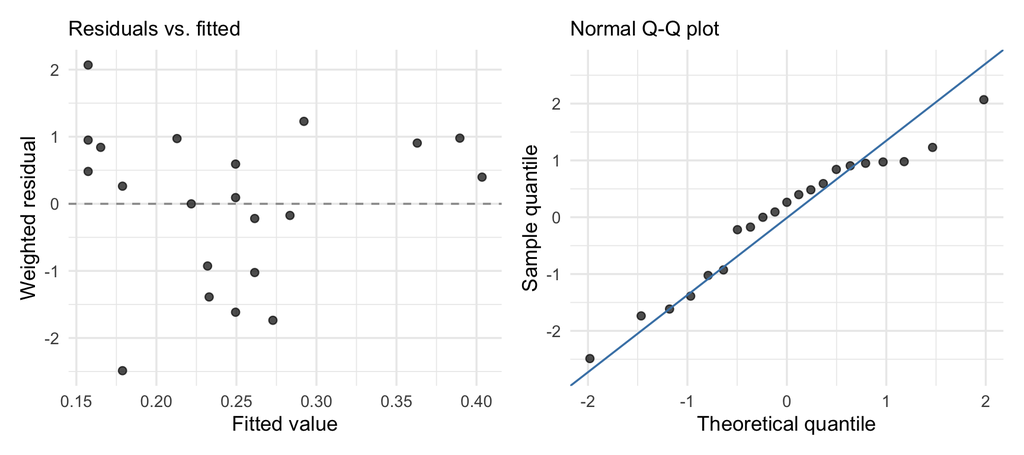

Figure 10: Residual diagnostics for Model 3 (beta regression with individual category scores).

```r
p_resid <- dat |>
  mutate(fitted = fitted(m3),
         resid  = residuals(m3, type = "sweighted2")) |>
  ggplot(aes(x = fitted, y = resid)) +
  geom_hline(yintercept = 0, linetype = "dashed", color = "grey60") +
  geom_point(size = 2, alpha = 0.7) +
  labs(x = "Fitted value", y = "Weighted residual",
       subtitle = "Residuals vs. fitted")

p_qq <- dat |>
  mutate(resid = residuals(m3, type = "sweighted2")) |>
  ggplot(aes(sample = resid)) +
  stat_qq(size = 2, alpha = 0.7) +
  stat_qq_line(color = "steelblue") +
  labs(x = "Theoretical quantile", y = "Sample quantile",
       subtitle = "Normal Q-Q plot")

p_resid + p_qq
```

These diagnostics do not need to look perfect to be useful, but Figure 10 helps distinguish a modestly noisy descriptive model from one that is plainly misspecified.

## Discussion

The analyses above evaluate risk tables as they have been used to date: a structured but still partly discretionary way to document concern and justify ABC reductions below `maxABC`. That perspective is useful, but it should be read alongside ongoing Council work on harvest control rules (HCRs). The Council’s 2026 HCR discussion paper frames alternative HCRs as one pathway for making harvest specifications more climate-resilient and more explicit about how risk and uncertainty enter ABC advice (NPFMC 2026). In that broader setting, the question is not only how risk-table scores have mapped to past reductions, but also which concerns should remain exceptional, case-specific judgments and which could be incorporated into pre-specified control rules.

Several patterns emerge:

1. **Population dynamics (P) scores are the strongest individual predictor** of larger reductions, consistent with the SSC weighting biomass trajectory and recruitment concerns heavily. That signal persists in the Bayesian mixed-effects fit in Table 10, although the posterior intervals remain fairly wide.
2. **Total score is a weak overall predictor.** The SSC clearly applies considerable judgment beyond what the risk scores encode—stock identity, economic context, and the specific nature of each concern all matter. This is consistent with the dispersion visible in Figure 4 and the comparison between aggregated and category-level models in Table 11.
3. **Outliers are informative.** EBS Pollock 2022 (A-2 only, 43% reduction) and EBS Pollock 2021 (A-2, E-2, F-2, only 11%) illustrate that stock-specific context can dominate the risk table signal. Those difficult cases are also evident in Figure 8, where even better performing models do not fully recover every stock-year outcome.
4. **Sample size limits model complexity.** With *n* = 21 observations across 13 stocks, more structured models are feasible but still uncertain. The Bayesian mixed-effects model in Table 10 helps by partially pooling repeated stock observations, yet the intervals remain wide enough that the fitted relationships should still be treated cautiously.
5. **The risk table is an input to, not a determinant of, the SSC decision.** Any predictive model should be understood as describing central tendency rather than prescribing outcomes.

The HCR discussion paper is directly relevant to interpreting that last point. It notes that the current groundfish `maxABC` HCR produces an upper bound on ABC from tier-specific formulas, but does not itself incorporate qualitative information about stock health, ecosystem conditions, or socioeconomic factors (NPFMC 2026). Risk tables have therefore served as a practical annual mechanism for documenting uncertainty outside the assessment model and supporting reductions below `maxABC`. Candidate HCRs under development would move some of that work into the control rule itself. Examples include HCRs that lower fishing mortality at high stock sizes to build biomass reserves and buffer against environmental shocks, and dynamic HCRs that adjust reference points or harvest rates in response to estimated changes in stock productivity or environmental covariates (NPFMC 2026).

If those HCRs are adopted for appropriate stocks, they could lessen the need to express recurring or predictable concerns as elevated risk-table scores. For example, if a dynamic HCR already reduces harvest rates when productivity declines, then a population-dynamics concern that previously would have triggered an elevated score and an ad hoc ABC reduction may instead be handled routinely through the HCR. Similarly, an HCR designed to preserve additional spawning biomass or age structure during high-biomass periods could reduce the need to use risk tables as the main vehicle for precaution when recruitment, growth, or environmental conditions are changing. In that future role, risk tables would remain important, but their strongest use would be to identify conditions outside the domain that the ordinary HCR was designed and tested to handle.

That distinction aligns with the HCR paper’s treatment of exceptional circumstances. A complete management procedure can define what the ordinary HCR is expected to handle routinely and what unusual conditions justify stepping outside the standard rule, such as survey failure, abrupt changes in productivity or distribution, marine heatwaves, assessment assumptions no longer being adequate, or new information showing that the management procedure is operating outside its tested domain (NPFMC 2026). This suggests a useful refinement for risk tables: elevated scores should not be a substitute for an HCR that can be specified analytically, but they are well suited to diagnosing exceptional circumstances, documenting evidence that the HCR may be outside its tested range, and triggering additional review or a pre-agreed contingency action.

The broader 2024 update emphasized that reductions from maximum permissible ABC have occurred for a limited set of stocks over the lifetime of the risk table process. Those stocks include one Alaska-wide stock (sablefish), eight stocks from the BSAI, and five from the GOA. In most cases where authors recommended a reduction, the SSC agreed, but there were also important exceptions where the SSC either imposed a reduction that authors had not proposed or declined to adopt a proposed reduction.

That pattern aligns with the fitted results here. The scores contain real signal, especially for population and broader multi-category concern, but they do not encode the full decision process. The SSC appears to use the risk table as a structured summary of uncertainty and concern, then combine it with stock-specific considerations, model behavior, and management judgment when setting the final buffer below maxABC.

For that reason, the models in this document are best used as exploratory benchmarks. They help summarize what kinds of score combinations have historically coincided with larger reductions, but they should not be treated as a mechanical rule for future assessments operating under a still-evolving risk table framework.

## References

NPFMC. 2026. *Risk and Uncertainty in the Groundfish and Crab Harvest Specifications Process and Development of Alternative Harvest Control Rules*. Discussion paper. North Pacific Fishery Management Council. https://meetings.npfmc.org/CommentReview/DownloadFile?p=19788990-cc5d-4590-9557-7e96e7e924ba.pdf&fileName=E2%20Harvest%20Control%20Rules.pdf.

Shotwell, S. Kalei, and Meaghan Bryan. 2024. *Groundfish Risk Table Report: 2024 Update*. Council presentation report. North Pacific Fishery Management Council.

Thompson, Grant G. 2019. *Analysis of Past BSAI and GOA Groundfish Plan Team Recommendations to Set ABC Below the Maximum Permissible Level*. Working paper. Alaska Fisheries Science Center, National Marine Fisheries Service, NOAA. https://meetings.npfmc.org/CommentReview/DownloadFile?p=f5899836-d32c-45a7-b565-93d1d44dc10c.pdf&fileName=Reverse-engineering+previous+ABC+reductions+3.pdf.

Thompson, Grant G., Jason Conner, S. Kalei Shotwell, et al. 2020. *Assessment of the Pacific Cod Stock in the Eastern Bering Sea*. Stock Assessment and Fishery Evaluation (SAFE) Report. Alaska Fisheries Science Center, National Marine Fisheries Service, NOAA. https://apps-afsc.fisheries.noaa.gov/refm/docs/2020/EBSpcod.pdf.